# 213 nasa05

Schlüsselwörter

Aufgaben, Statistik, Prognose, Modellierung, R, Datenanalyse, Regression

Viele Quellen berichten Klimadaten unserer Erde, z.B. auch [National Aeronautics and Space Administration - Goddard Institute for Space Studies](https://data.giss.nasa.gov/gistemp/).

Von dieser Quelle beziehen wir [diesen Datensatz](https://data.giss.nasa.gov/gistemp/tabledata_v4/GLB.Ts+dSST.csv).

Die Datensatz sind auf der Webseite wie folgt beschrieben:

*Tables of Global and Hemispheric Monthly Means and Zonal Annual Means*

Combined Land-Surface Air and Sea-Surface Water Temperature Anomalies (Land-Ocean Temperature Index, L-OTI)

The following are plain-text files in tabular format of temperature anomalies, i.e. *deviations from the corresponding 1951-1980 means*.

> Global-mean monthly, seasonal, and annual means, 1880-present, updated through most recent month: TXT, CSV

Starten Sie zunächst das R-Paket `tidyverse` falls noch nicht geschehen.

```
library(tidyverse)
```

Zum Animieren verwenden wir diese Pakete:

```
library(gganimate)
library(plotly)
```

Importieren Sie dann die Daten:

```
data_path <- "https://data.giss.nasa.gov/gistemp/tabledata_v4/GLB.Ts+dSST.csv"
d <- read_csv(data_path, skip = 1)
```

Wir lassen die 1. Zeile des Datensatzes aus (Argument `skip`), da dort *Metadaten* stehen, also keine Daten, sondern Informationen (Daten) zu den eigentlichen Daten.

**Aufgabe**

Hinweise:

- Sie müssen zuerst die Dekade als neue Spalte berechnen.

### 213.0.1 Daten aufbereiten

Character in Zahlen umwandeln:

```
d2 <-
  d %>%
  select(Year:Dec) %>%
  mutate(across(Apr:Dec, as.numeric))
d3 <-
  d2 %>%
  pivot_longer(-Year, values_to = "temp", names_to = "month")
months <-
  tibble(
    month = d3$month[1:12],
    month_num = 1:12
  )
d3 <-
  d3 %>%
  full_join(months)
```

### 213.0.3 Animation mit plotly

```
d3 %>%
plot_ly(
  x = ~Year,
  y = ~temp,
  #color = ~month,
  frame = ~Year,
  hoverinfo = "text",
  text = ~Year,
  type = "scatter",
  mode = "markers"
)
```

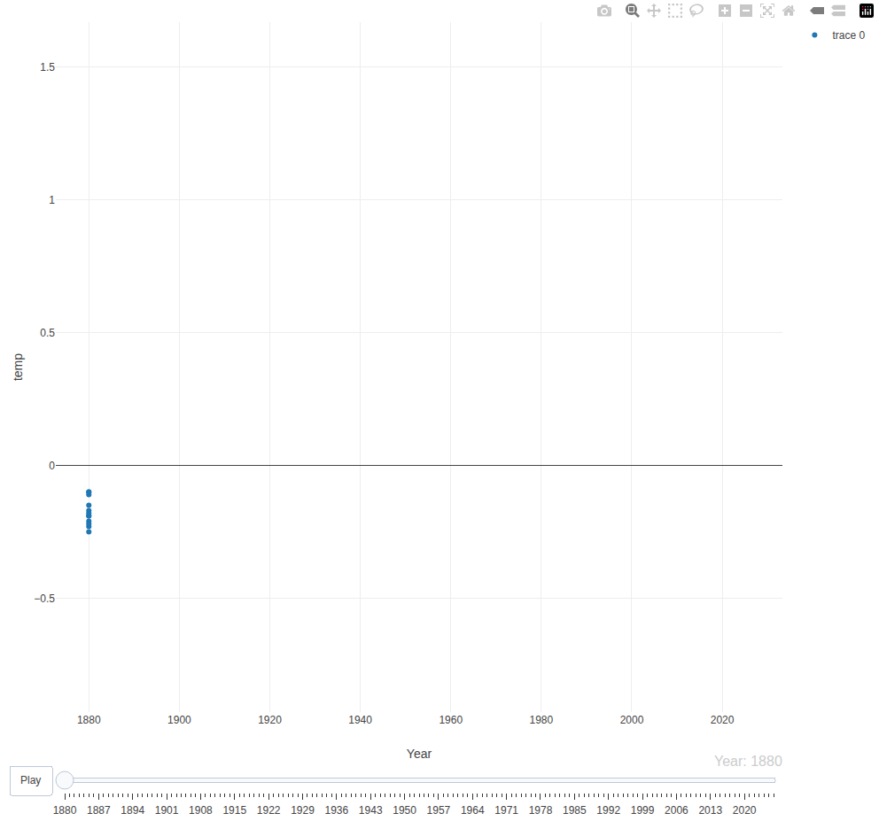

```
d3 %>%
plot_ly(
  x = ~Year,
  y = ~temp,
  color = ~month_num,
  frame = ~Year,
  hoverinfo = "text",
  text = ~Year,
  type = "scatter",
  mode = "markers"
)
```

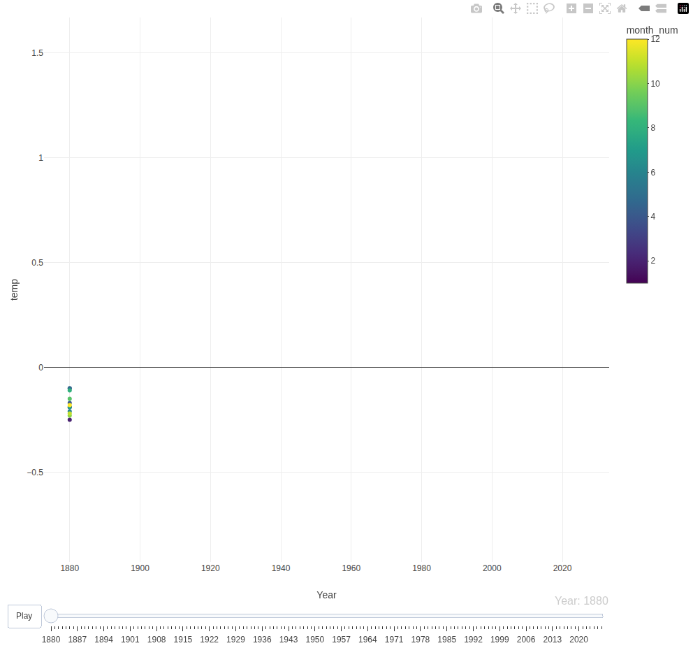

### 213.0.4 Fazit

Falls Sie Teile der R-Syntax nicht kennen: Machen Sie sich nichts daraus. Be happy 😄

Aufgabenname: `nasa05`

Categories:

- data
- eda
- lagemaße
- vis
- animation
- string